# Support Vector

# Support Vector Classifier

We will demonstrate the use of a support vector classifier on a two-dimensional example so that we can plot the resulting decision boundary.

We begin by generating the observations, which belong to two classes, and checking whether the classes are linearly separable.

The graph shows that they are not linearly separable.

Note that in order for the svm() function to perform classification (as opposed to SVM-based regression), we must encode the response as a factor variable.

We then create a data frame with the response coded as a factor.

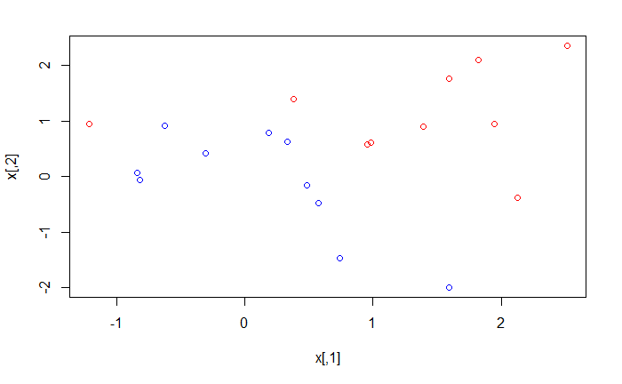

```r
set.seed(1)
x=matrix(rnorm(20*2), ncol=2) #simluate a 10x2 matrix
y=c(rep(-1,10), rep(1,10)) #a vector with 20 elements
x[y==1,]=x[y==1,] + 1 #add 1 to the last 10 rows of x
plot(x, col=(3-y)) #col 2 correspond to red (y=1) and col 4 correpond to blue (y=-1)
```

```r
dat=data.frame(x=x, y=as.factor(y))
```

Next, we fit the support vector classifier.

We use the svm() function from e1071 library. The svm() function can be used to fit a support vector classifier when the argument kernel=“linear” is used.

This function uses a slightly different formulation. A cost argument allows us to specify the cost of a violation to the margin. - When the cost argument is small, then the margins will be wide and many support vectors will be on the margin or will violate the margin. - When the cost argument is large, then the margins will be narrow and there will be few support vectors on the margin or violating the margin.

The argument scale=FALSE tells the svm() function not to scale each feature to have mean zero or standard deviation one.

We can then plot the support vector classifier obtained.

The region of feature space that will be assigned to the ???1 class is shown in light blue, and the region that will be assigned to the +1 class is shown in purple.

The decision boundary between the two classes is linear (though due to the way in which the plotting function is implemented the boundary looks uneven in the plot).

Note that here the second feature is plotted on the x-axis and the first feature is plotted on the y-axis, in contrast to the behavior of the usual plot() function in R.

The support vectors are plotted as crosses and the remaining observations are plotted as circles.

```r
library(e1071)
svmfit=svm(y???., data=dat, kernel="linear", cost=10, scale=FALSE)
plot(svmfit, dat) #this will initiate the plot.svm() function

svmfit$index #there are seven support vectors here and we can determine their identities
```

[output not shown]

We can obtain some basic information about the support vector classifier fit using the summary() command.

If we instead used a smaller value of the cost parameter, we will obtain a larger number of support vectors, because the margin is now wider.

Unfortunately, the svm() function does not explicitly output the coefficients of the linear decision boundary obtained when the support vector classifier is fit, nor does it output the width of the margin.

```r
summary(svmfit)

svmfit=svm(y???., data=dat, kernel="linear", cost=0.1, scale=FALSE)
plot(svmfit, dat)
svmfit$index
```

[output not shown]

## Cross-validation

The e1071 library includes a built-in function, tune(), to perform cross-validation.

By default, tune() performs ten-fold cross-validation on a set of models of interest.

In order to use this function, we pass in relevant information about the set of models that are under consideration.

We want to compare SVMs with a linear kernel, using a range of values of the cost parameter.

We can easily access the cross-validation errors for each of these models using the summary() command.

```r
set.seed(1)
tune.out=tune(svm, y???., data=dat, kernel="linear", ranges=list(cost=c(0.001, 0.01, 0.1, 1,5,10,100)))
summary(tune.out)

bestmod=tune.out$best.model #tune() function stores the best model obtained and we can access it
summary(bestmod)
```

[output not shown]

We want to calculate the test error of this best model chosen by cross-validation.

We begin by generating a test data set.

```r
xtest=matrix(rnorm (20*2), ncol=2)
ytest=sample(c(-1,1), 20, rep=TRUE)
xtest[ytest==1,]=xtest[ytest==1,] + 1
testdat=data.frame(x=xtest, y=as.factor(ytest))
```

Now we predict the class labels of these test observations.

The predict() function can be used to predict the class label on a set of test observations, at any given value of the cost parameter.

With this value of cost, 19 of the 20 test observations are correctly classified.

```r
ypred=predict(bestmod, testdat)
table(predict=ypred, truth=testdat$y )
```

```
       truth
predict -1  1
     -1 11  1
     1   0  8
```

We consider a situation in which the two classes are linearly separable. Then we can find a separating hyperplane using the svm() function.

We first further separate the two classes in our simulated data so that they are linearly separable.

We fit the support vector classifier and plot the resulting hyperplane, using a very large value of cost so that no observations are misclassified.

Only three support vectors were used and the margin is very narrow (because the observations that are not support vectors, indicated as circles, are very close to the decision boundary).

It seems likely that this model will perform poorly on test data.

```r
x[y==1,]=x[y==1,]+0.5 #add 0.5 to the last 10 rows of x
plot(x, col=(y+5)/2, pch =19)

dat=data.frame(x=x, y=as.factor(y))
svmfit=svm(y???., data=dat, kernel="linear", cost=1e5)
summary(svmfit)
plot(svmfit, dat)
```

[output not shown]

We now try a smaller value of cost.

However, we obtain a much wider margin and make use of 7 support vectors.

It seems likely that this model will perform better on test data than the model with cost=1e5.

```r
svmfit=svm(y???., data=dat, kernel="linear", cost=1)
summary(svmfit)
plot(svmfit, dat)
```

[output not shown]

# Support Vector Machine

To fit an SVM with a polynomial kernel, we use kernel=“polynomial”, and the degree argument to specify a degree d for the polynomial kernel.

To fit an SVM with a radial kernel we use kernel=“radial”, and the gamma argument to specify a value of ?? for the radial kernel.

We first generate some data with a non-linear class boundary.

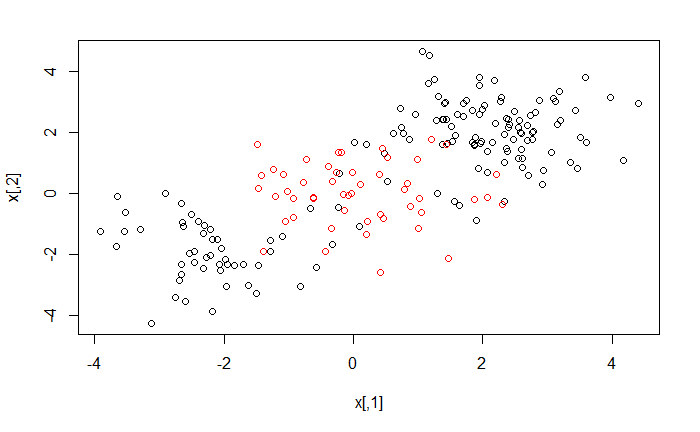

```r
set.seed(1)
x=matrix(rnorm(200*2) , ncol=2)
x[1:100,]=x[1:100,]+2
x[101:150,]=x[101:150,]-2
y=c(rep(1,150), rep(2,50))
dat=data.frame(x=x, y=as.factor(y))
plot(x, col=y) ##col 1 correspond to black (y=1) and col 2 correpond to red (y=2)
```

The data is randomly split into training and testing groups.

We then fit the training data using the svm() function with a radial kernel and ??=1.

The summary() function can be used to obtain some information about the SVM fit.

We can see from the figure that there are a fair number of training errors in this SVM fit (because some of the red crosses, which are supposed to be in purple region, are now in light blue region and vice versa).

If we increase the value of cost, we can reduce the number of training errors since the cost of violation to the margin is now higher.

However, this comes at the price of a more irregular decision boundary that seems to be at risk of overfitting the data.

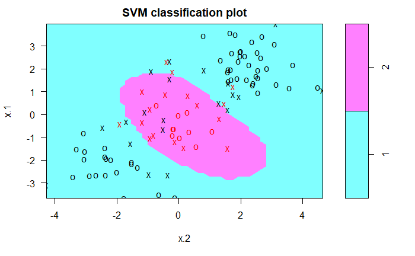

```r
train=sample(200,100)
svmfit=svm(y~., data=dat[train,], kernel="radial", gamma=1, cost=1)
plot(svmfit, dat[train,])
```

```r
summary(svmfit)
```

```
Call:
svm(formula = y ~ ., data = dat[train, ], kernel = "radial", gamma = 1, cost = 1)


Parameters:
   SVM-Type:  C-classification
 SVM-Kernel:  radial
       cost:  1
      gamma:  1

Number of Support Vectors:  37

 ( 17 20 )


Number of Classes:  2

Levels:
 1 2
```

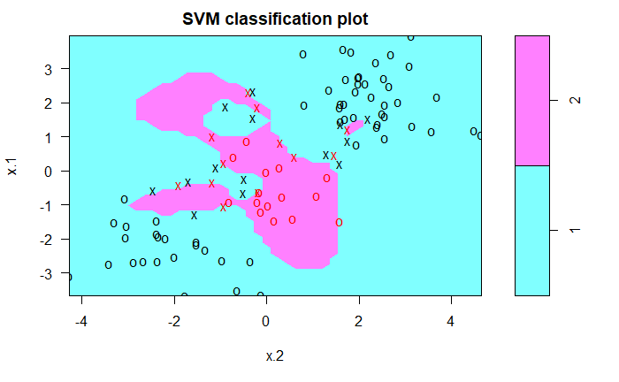

```r
svmfit=svm(y~., data=dat[train,], kernel="radial", gamma=1, cost=1e5)
plot(svmfit, dat[train,])
```

## Cross-validation

We can perform cross-validation using tune() to select the best choice of cost and gamma for a SVM with radial kernel.

We can view the test set predictions for this model by applying the predict() function to the data.

Notice that to do this we subset the dataframe using -train as an index set.

We see that 10 % of test observations are misclassified by this SVM.

```r
set.seed(1)
tune.out=tune(svm, y???., data=dat[train,], kernel="radial", ranges=list(cost=c(0.1,1,10,100,1000), gamma=c(0.5,1,2,3,4)))
summary(tune.out)

ypred=predict(tune.out$best.model, newdata=dat[-train,])
table(true=dat[-train, "y"], pred=ypred)

(7+3)/100
```

[output not shown]

# ROC Curves

The ROCR package can be used to produce ROC curves.

We first write a short function to plot an ROC curve given a vector containing a numerical score for each observation (pred), and a vector containing the class label for each observation (truth).

SVMs and support vector classifiers output class labels for each observation. However, it is also possible to obtain fitted values for each observation, which are the numerical scores used to obtain the class labels.

In essence, the sign of the fitted value determines on which side of the decision boundary the observation lies. - If the fitted value exceeds zero, then the observation is assigned to one class. - If it is less than zero, then it is assigned to the other.

In order to obtain the fitted values for a given SVM model fit, we use decision.values=TRUE when fitting svm(). Then the predict() function will output the fitted values.

Looking at the ROC plot, SVM appears to be producing accurate predictions.

By increasing ?? we can produce a more flexible fit and generate further improvements in accuracy on training data.

When we compute the ROC curves on the test data, the model with ??=2 appears to provide the most accurate results.

```r
library(ROCR)
rocplot=function (pred, truth, ...){
  predob=prediction(pred, truth)
  perf=performance(predob, "tpr", "fpr") #tpr and fpr stands for true positive rate and false positive rate respectively
  plot(perf, ...)}
svmfit.opt=svm(y~., data=dat[train,], kernel="radial", gamma=2, cost=1, decision.values=T)
fitted=attributes(predict(svmfit.opt, dat[train,], decision.values=TRUE))$decision.values
par(mfrow=c(1,2))
rocplot(fitted, dat[train, "y"], main="Training Data")
#Use a higher value of gamma
svmfit.flex=svm(y~., data=dat[train,], kernel="radial", gamma=50, cost=1, decision.values=T)
fitted=attributes(predict(svmfit.flex, dat[train,], decision.values=T))$decision.values
rocplot(fitted, dat[train, "y"], add=T, col="red")
```

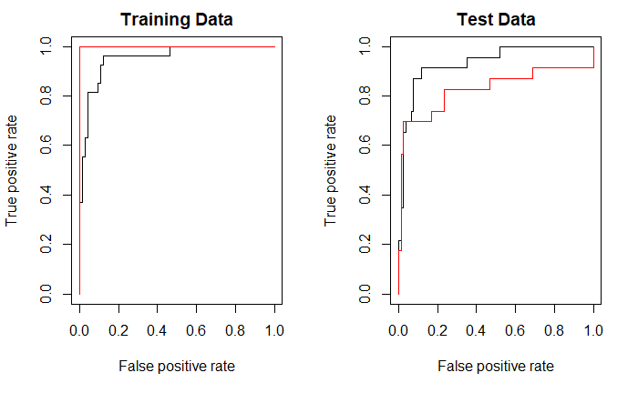

```r
#ROC curves on test data
fitted=attributes(predict(svmfit.opt, dat[-train,], decision.values=TRUE))$decision.values
rocplot(fitted, dat[-train, "y"], main="Test Data")
fitted=attributes(predict(svmfit.flex, dat[-train,], decision.values=T))$decision.values
rocplot(fitted, dat[-train, "y"], add=T, col="red")
```

# SVM with Multiple Classes

If the response is a factor containing more than two levels, then the svm() function will perform multi-class classification using the one-versus-one approach.

We explore that setting here by generating a third class of observations.

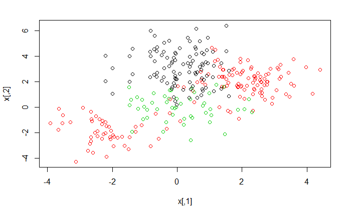

```r
set.seed(1)
x=rbind(x, matrix(rnorm(50*2), ncol=2)) #add another 50 rows to the previous X matrix
y=c(y, rep(0,50)) #add another 50 elements to the previous y vector
x[y==0, 2]=x[y==0, 2] + 2
dat=data.frame(x=x, y=as.factor(y))
plot(x, col=(y+1)) #col 1 correspond to black (y=1), col 2 correpond to red (y=2) and col 3 correpond to green (y=3)
```

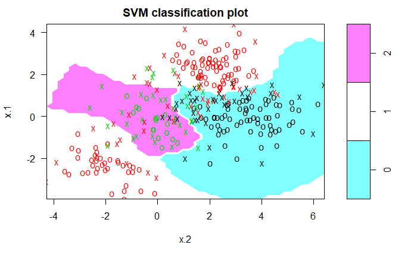

```r
svmfit=svm(y~., data=dat, kernel="radial", cost=10, gamma=1)
plot(svmfit, dat)
```

## Support Vector Regression

The e1071 library can also be used to perform support vector regression, if the response vector that is passed in to svm() is numerical rather than a factor.

# Application to Gene Expression Data

We now examine the Khan data set, which consists of a number of tissue samples corresponding to four distinct types of small round blue cell tumors.

The data set consists of training data, xtrain and ytrain, and testing data, xtest and ytest.

This data set consists of expression measurements for 2,308 genes. The training and test sets consist of 63 and 20 observations respectively.

```r
library(ISLR)
names(Khan)
```

```
[1] "xtrain" "xtest"  "ytrain" "ytest"
```

```r
dim(Khan$xtrain)
```

```
[1]   63 2308
```

```r
dim(Khan$xtest)
```

```
[1]   20 2308
```

```r
length(Khan$ytrain)
```

```
[1] 63
```

```r
length(Khan$ytest)
```

```
[1] 20
```

```r
table(Khan$ytrain)
```

```
 1  2  3  4
 8 23 12 20
```

```r
table(Khan$ytest)
```

```
1 2 3 4
3 6 6 5
```

We will use a support vector approach to predict cancer subtype using gene expression measurements.

In this data set, there are a very large number of features relative to the number of observations (2308 vs 63).

This suggests that we should use a linear kernel, because the additional flexibility that will result from using a polynomial or radial kernel is unnecessary.

We see that there are no training errors. In fact, this is not surprising, because the large number of variables relative to the number of observations implies that it is easy to find hyperplanes that fully separate the classes.

```r
dat=data.frame(x=Khan$xtrain, y=as.factor(Khan$ytrain))
out=svm(y~., data=dat, kernel="linear", cost=10)
summary(out)
```

```
Call:
svm(formula = y ~ ., data = dat, kernel = "linear", cost = 10)


Parameters:
   SVM-Type:  C-classification
 SVM-Kernel:  linear
       cost:  10
      gamma:  0.0004332756

Number of Support Vectors:  58

 ( 20 20 11 7 )


Number of Classes:  4

Levels:
 1 2 3 4
```

```r
table(out$fitted, dat$y)
```

```
     1  2  3  4
  1  8  0  0  0
  2  0 23  0  0
  3  0  0 12  0
  4  0  0  0 20
```

We check its performance on the test observations.

We see that using cost=10 yields two test set errors on this data.

```r
dat.te=data.frame(x=Khan$xtest, y=as.factor(Khan$ytest))
pred.te=predict(out, newdata=dat.te)
table(pred.te, dat.te$y)
```

```
pred.te 1 2 3 4
      1 3 0 0 0
      2 0 6 2 0
      3 0 0 4 0
      4 0 0 0 5
```